```python
import matplotlib.pyplot as plt
import numpy as np
```

```python
# Helper function to filter list with elements that are close to each other for a given (or not) threshold.

def filter_list(L, threshold=1e-5):
    F = []
    for i in L:
        include_element = True
        for j in F:
            if abs(i - j) < threshold:
                include_element = False
                break
        if include_element:
            F.append(i)
    return F

''' Helper function that finds the minimum distance of a list with 0.5 to be used when approximating the second Feigenbaum number '''

def find_min_distance(L):
    D = []
    for i in L:
        if i!=0.5:
            D.append(abs(0.5-i))
    return min(D)

''' Helper function that finds the minimum distance of a list with 0.25 to be used when approximating the second Feigenbaum constant for
the perturbed case'''

def find_min_distance_p(L):
    D = []
    for i in L:
        if i!=0.25:
            D.append(abs(0.25-i))
    return min(D)
```

```python
def q(x, a):
    return a * x * (1 - x)

    # Wave effect perturbation    - 0.1* a*(1/(60*np.pi)*np.sin(20*np.pi*(np.exp(x))))

def calculate_orbit(num_iterations, a, initial_value):
    orbit = [initial_value, q(initial_value,a)]

    for i in range(3, num_iterations + 1):
        orbit.append(q(orbit[-1],a))

    return orbit
```

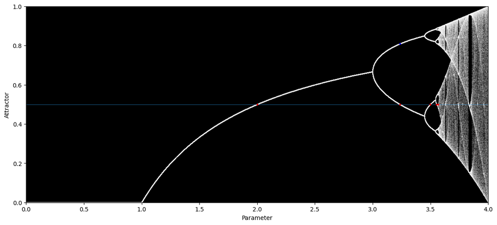

```python
def bifurcation_diagram(num_iterations, a_start, a_end, initial_value):
    points = []

    for a in np.arange(a_start, a_end, (a_end-a_start)/40000):
        orbit= calculate_orbit(num_iterations, a, initial_value)
        for i in range(int(0.95*num_iterations), num_iterations):
            points.append([a, orbit[i]])

    points = np.array(points)

    @np.vectorize
    def constant_function(x):
        return 0.5



    plt.figure(figsize=(14, 6),facecolor='white')
    plt.plot(points[:, 0], points[:, 1], '4', markersize=(a_end-a_start)/5, color='white', alpha=1-(a_end-a_start)/4.4)  # Use 'bo' for filled circles
    plt.plot(np.linspace(0, 4, 100), constant_function(np.linspace(0, 4, 100)),linewidth=0.5)
    plt.plot([2,1+np.sqrt(5),3.4985616993,3.5546408628,3.5666673799],[0.5,0.5,0.5,0.5,0.5], 'ro', markersize=2)
    plt.plot([1+np.sqrt(5)],[0.8090169943749475], 'bo', markersize=2)

    ax=plt.gca()
    ax.set_facecolor('xkcd:black')
    plt.xlabel('Parameter')
    plt.xlim(a_start,a_end)
    plt.ylabel('Attractor')
    plt.ylim(0,1)
    plt.grid(False)
    plt.show()

bifurcation_diagram(1000,0, 4, 0.5)
```

- Our goal is to approximate the accumulation rate of the bifurcation parameters. To do so we follow Briggs http://keithbriggs.info/documents/how-to-calc.pdf where he conjectures that we do not need to approximate the period-doubling bifurcation values, but it is enough to approximate the parameter values where a super-stable $2^n$ periodic orbit occurs. In the case of the logistic map, since we know that the only critical point is $\frac{1}{2}$, the above is equivalent to finding the parameter values where $\frac{1}{2}$ belongs to the attractive periodic orbit.
- To do so, we consider the recursive sequence of polynomials $$p_k(a)=a\,p_{k-1}(a) (1-p_{k-1}(a))$$ with $p_0(a)=\frac{1}{2}$. THhe problem then simplifies to a root finding problem, where we can use Newton method to find the roots of $$ p_{2^n}(a)=\frac{1}{2} \text{ for } n=1,2,3,\dots$$
- We find the derivative w.r.t $a$ $$ p'_k(a)=p_{k-1}(a)+a\, p'_{k-1}(a)-(p_{k-1}(a))^2-2a\, p_{k-1}(a)\,p'_{k-1}(a) $$
- We already know that $\frac{1}{2}$ is a super-stable fixed point for $a=2$ and using the above we can calculate that it is part of the super-stable 2-period for $a=1+\sqrt{5}\approx 3.23$. We will use these values to make an accurate guess for the next parameter value where $\frac{1}{2}$ will be a super-stable periodic point (now of 4-periodic orbit). Using the fact that the ratio of the differences of three consecutive parameter values should approximate the Feigenbaum constant $\delta\approx 4.6692016$ our guess for each $n$ is: $$ a_n^0 = a_{n-1}+\frac{a_{n-1}-a_{n-2}}{\delta_{n-1}} $$ for $n=2,3,4,\dots$. Where $$\delta_n = \frac{a_{n-1}-a_{n-2}}{a_n-a_{n-1}}$$ for $n=2,3,4,\dots$ and $\delta_1=4.7$. We just arrange for $\delta_1$ to be such that the first guess for the 4-period will be close to the root.
- As Briggs mentions `the algorithm depends on finding the correct zero by Newton's method of a high degree polynomial with many closely spaced zeros` to note the importance of the guess for the Newton method.

```python
def constant(m, n, a):
    N = 2 ** n

    for _ in range(m):
        b = 0.5
        b_prime = 0

        for _ in range(N):
            b_prime = b + a * b_prime - b**2 -2*a*b*b_prime
            b = a*b-a*b**2

        a = a - (b-0.5) / b_prime
    return a

def delta(N):
    # N: gives the iteration of calculating delta (d)
    # d: delta is the Feigenbaum constant

    a = [2, 1+np.sqrt(5)]
    d = 4.7
    deltas=[]

    print("{:^3}\t{:^12}\t{:^16}".format("i", "a_i", "delta_i"))

    for i in range(2, N + 1):
        approximation = a[-1] + ((a[-1] - a[-2]) / d)
        a.append(constant(500, i, approximation))
        d = (a[-2] - a[-3]) / (a[-1] - a[-2])
        deltas.append(d)

        print("{:>=1}\t{:12.10f}\t{:16.10f}".format(i, a[-1], d))
    return a, deltas

l=delta(11)

parameters=l[0][1:]
feigen = l[1][-1]

print('------------------------------------------------------')



alpha=[]

for a in parameters:
    sso = calculate_orbit(10000, a, 0.5)
    sso = filter_list(sso)
    alpha.append(find_min_distance(sso))
print("The approximated second feigenbaum constant is", feigen)
print("The approximated second feigenbaum constant is \t{:12.10f}".format(alpha[-2]/alpha[-1]))
print('------------------------------------------------------')
```

```
 i 	    a_i     	    delta_i
2	3.4985616993	    4.7089430135
3	3.5546408628	    4.6807709980
4	3.5666673799	    4.6629596111
5	3.5692435316	    4.6684039259
6	3.5697952937	    4.6689537410
7	3.5699134654	    4.6691571815
8	3.5699387742	    4.6691910003
9	3.5699441946	    4.6691994723
10	3.5699453555	    4.6692011403
11	3.5699456041	    4.6692012969
------------------------------------------------------
The approximated second feigenbaum constant is 4.669201296858572
The approximated second feigenbaum constant is 	2.5029078007
------------------------------------------------------
```

Now we turn to another unimodal map, namely $$\tilde{q}_a=\frac{a\, \sin(\pi\sqrt{x})}{4}$$ for parameter values in $[0,4]$. It is not hard to see that it is indeed a unimodal map and has its unique critical point at $x=\frac{1}{4}$.

```python
def q_p(x, a):   # wherever we use _p we are referring to the perturbed case
    return (a*np.sin(np.pi*np.sqrt(x)))/4

##def fixed_points(f):
##    return [x for x in np.roots([f - x, 0])]

def calculate_orbit_p(num_iterations, a, initial_value):
    orbit = [initial_value, q_p(initial_value,a)]

    for i in range(3, num_iterations + 1):
        orbit.append(q_p(orbit[-1],a))

    return orbit
```

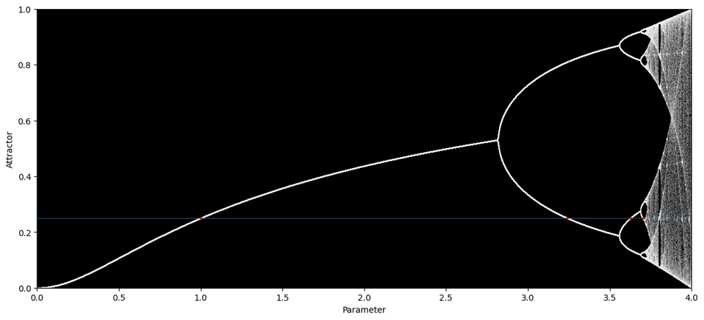

```python
def bifurcation_diagram_p(num_iterations, a_start, a_end, initial_value):
    points = []

    for a in np.arange(a_start, a_end, (a_end-a_start)/40000):
        orbit= calculate_orbit_p(num_iterations, a, initial_value)
        for i in range(int(0.95*num_iterations), num_iterations):
            points.append([a, orbit[i]])

    points = np.array(points)

    @np.vectorize
    def constant_function(x):
        return 0.25



    plt.figure(figsize=(14, 6),facecolor='white')
    plt.plot(points[:, 0], points[:, 1], '4', markersize=(a_end-a_start)/5, color='white', alpha=1-(a_end-a_start)/4.4)
    plt.plot(np.linspace(0, 4, 100), constant_function(np.linspace(0, 4, 100)),linewidth=0.5)
    plt.plot([1,3.24117285739,3.6270691058,3.7025008404],[0.25,0.25,0.25,0.25], 'ro', markersize=2)

    ax=plt.gca()
    ax.set_facecolor('xkcd:black')
    plt.xlabel('Parameter')
    plt.xlim(a_start,a_end)
    plt.ylabel('Attractor')
    plt.ylim(0,1)
    plt.grid(False)
    plt.show()

bifurcation_diagram_p(1000,0, 4, 0.25)
```

We note that the bifurcation diagram looks different from the bifurcation diagram of the logistic map, the tines of period doubling bifurcation seem wider and it also seems as if the system enters chaos much later than the logistic map does. Another difference is that the period-3 window is now much thinner.

```python
def constant_p(m, n, a):

    N = 2 ** n

    for _ in range(m):
        b = 0.25
        b_prime = -1.035

        for _ in range(N):
            b_prime = 0.25*(np.sin(np.pi*np.sqrt(b))+a*np.cos(np.pi*np.sqrt(b))*np.pi*(b_prime/(2*np.sqrt(b))))
            b = 0.25*a * np.sin(np.pi*np.sqrt(b))

        a = a - (b-0.25) / b_prime
    return a

def delta_p(N):
    # N: gives the iteration of calculating delta (d)
    # d: delta - the feigenbaum constant

    a = [1, 3.24117285739966]
    d = 5.7

    deltas=[]

    print("{:^3}\t{:^12}\t{:^16}".format("i", "a_i", "delta_i"))

    for i in range(2, N + 1):
        approximation = a[-1] + ((a[-1] - a[-2]) / d)
        a.append(constant_p(500, i, approximation))
        d = (a[-2] - a[-3]) / (a[-1] - a[-2])
        deltas.append(d)

        print("{:>=1}\t{:12.10f}\t{:16.10f}".format(i, a[-1], d))
    return a, deltas

l_p=delta_p(11)

parameters_p=l_p[0][1:]
feigen_p = l_p[1][-1]

print('------------------------------------------------------')



alpha_p=[]

for a in parameters_p:
    sso_p = calculate_orbit_p(10000, a, 0.25)
    sso_p = filter_list(sso_p,1e-8)
    alpha_p.append(find_min_distance_p(sso_p))

print("The approximated second feigenbaum constant is", feigen_p)
print("The approximated second feigenbaum constant is \t{:12.10f}".format(alpha_p[-2]/alpha_p[-1]))
print('------------------------------------------------------')
```

```
 i 	    a_i     	    delta_i
2	3.6270691058	    5.8077083325
3	3.7025008404	    5.1158342091
4	3.7184914466	    4.7172529967
5	3.7219088192	    4.6792105458
6	3.7226403865	    4.6713032437
7	3.7227970508	    4.6696480449
8	3.7228306028	    4.6692975834
9	3.7228377886	    4.6692220924
10	3.7228393276	    4.6692060358
11	3.7228396572	    4.6692026577
------------------------------------------------------
The approximated second feigenbaum constant is 4.669202657670067
The approximated second feigenbaum constant is 	2.5026249447
------------------------------------------------------
```

**Comment:** I attempted to calculate the first Feigenbaum constant using the conventional method, which involves identifying the parameter values where period doubling occurs. I initiated the process with the easily computable value of $1+\sqrt{6}$ and subsequently refined my approximations by evaluating and filtering the orbits of points in close proximity to the anticipated period-doubling parameters. Starting from the initial parameter, I narrowed down the interval around the next anticipated period-doubling parameter, which I guessed in a similar way to the initial guess in the Newton method. Within these intervals, I computed the average derivatives of each point and multiplied them. I flagged a parameter value as a potential period-doubling parameter when the absolute average derivative was sufficiently close to 1. This iterative process was then repeated for progressively narrower intervals. However, I encountered challenges related to precision. Discrepancies arose when comparing my calculated bifurcation values with those found online (https://mathworld.wolfram.com/LogisticMap.html), with some deviations being quite substantial. Additionally, during certain implementations, adjustments to the initial conditions occasionally led to bifurcation parameters exceeding 3.57, placing them within the realm of chaos. This discrepancy suggested a need for alternative way to approximate the first Feigenbaum constant, and that's when I found Briggs' document. If you have any initial thoughts on potential reasons for these issues, I would be eager to hear them.